# PGT Race

The goal of this notebook is to provide a fair comparison of the convergence properties of the various PGT algorithms sampling algorithms we have been working with. In general, this will require:

- Comparing PGT approaches (trembling vs off path) with the traditional PGT algorithms.
- Comparing the convergence properties to the "true" distribution
- Comparing different sampling approaches (Metropolis-Hastings vs Simple Sampling)
- Sensitivity Analysis (how do the results differ as we make slight modification to the game structure)

## General Setup

The general setup is an $n$ player market competition game with stochastic demand.

### Experiment set 1 - Two player , perfect information, one "round", "traditional" PGT analysis

Summary : In this initial experiment, nature selects an inverse demand function, the leader, $L$, observes the inverse demand function and selects a quantity, the follower, $F$, observes both the inverse demand function and $L$'s action and then selects a quantity.

#### Experiment 1.1

- Demand is $P=50-Q$ with probability .5 and $P=50-2Q$ with probability .5
- Each firm has constant marginal cost of $1$
- The Stackelberg equilibrium when demand is $P=50-Q$ is $(24.5, 12.25)$
- The Stackelberg equilibrium when demand is $P=50-2Q$ is $(12.25, 6.125)$
- The leader and follower both have the same 3 actions $\{ 24,12,6\}$
- The leader has 9 possible strategies
- The follower has 729 possible strategies
- There are 6561 total strategy profiles
- There are 105 pure strategy Nash equilibria

```python
import numpy as np
import itertools
from matplotlib import pyplot as plt
%matplotlib inline
from collections import defaultdict
import time
from adsy.display import extended_styles
from collections import Counter
```

```python
extended_styles()
```

Toggle Input

```python
nature_space = {"H": (50,1), "L": (50,2)}
nature_probs = {"H": .5, "L" : .5}
l_mc = 1.
f_mc = 1.
l_actions = {"24": 24., "12": 12., "6": 6.}
f_actions = {"24": 24., "12": 12., "6": 6.}
```

```python
class OneRoundPerfectInformationStackelbergGame(object):
    def __init__(self, nature_space, p1_actions, p2_actions, l_mc, f_mc,
                nature_probs):
        """
        """
        self.sequence = sequence
        self.nature_space = nature_space
        self.p1_actions = p1_actions
        self.p2_actions = p2_actions
        self.l_mc = l_mc
        self.f_mc = f_mc
        self.p1_strats, self.p2_strats = self.gen_strats()
        self.jointprofiles = list(itertools.product(self.p1_strats, self.p2_strats))
        self.nature_probs = nature_probs

    def gen_strats(self):
        """
        Generates Strategies From Actions
        """
        p1tuples = list(itertools.product(self.p1_actions.values(), repeat = len(self.nature_space)))
        p1_strats = [dict(zip( self.nature_space.keys(), x)) for x in p1tuples]
        p2tuples = list(itertools.product(self.p2_actions.values(), repeat = len(self.nature_space) *
                                         len(self.p1_actions)))
        p2infosets = [x + y for x in self.nature_space.keys() for y in self.p1_actions.keys()]
        p2_strats = [dict(zip( p2infosets, x)) for x in p2tuples]
        return p1_strats, p2_strats


    def get_EU(self, p1, p2):
        """
        Gets expected utility given player 1 and player 2's strategy
        """
        p1u = 0
        p2u = 0
        for move, params in self.nature_space.iteritems():
            p = self.nature_probs[move]
            intercept = params[0]
            slope = params[1]
            p1q = p1[move]
            p2q = p2[move+str(int(p1q))]
            price =  max(0, intercept - slope * (p1q + p2q))
            p1u += p*(price *p1q - self.l_mc*p1q)
            p2u += p*(price *p2q - self.f_mc*p2q)
        return p1u, p2u

    def exhaustive_pgt(self):
        """
        Returns the un-exponentiated intelligences for all profiles
        in self.jointprofiles
        """
        intelligences = []
        for s in self.jointprofiles:
            p1_strat = s[0]
            p2_strat = s[1]
            p1eu, p2eu = self.get_EU(p1_strat, p2_strat)
            # First get intelligence of p1
            p1_num_worse = 0
            p1_numalt = 0
            for p1_alt in self.p1_strats:
                if p1_alt !=p1_strat:
                    p1_numalt += 1
                    if self.get_EU(p1_alt, p2_strat)[0] <= p1eu:
                        p1_num_worse += 1
            # First get intelligence of p2
            p2_num_worse = 0
            p2_numalt = 0
            for p2_alt in self.p2_strats:
                if p2_alt !=p2_strat:
                    p2_numalt += 1
                    if self.get_EU(p1_strat, p2_alt)[1] <= p2eu:
                        p2_num_worse += 1

            intelligences.append( p1_num_worse/float(p1_numalt) * p2_num_worse/float(p2_numalt))
        return intelligences

    def exhaustive_distribution(self, f, jointprofiles = None, intels=None, power=1, bar=True):
        """
        The function argument computes the quantity of interest where the
        first argument is player 1's profile and the second argument is
        player 2's profile.

        Returns "bar" dict of distribution as well as cdf support and
        prob
        """
        if intels is None:
            intels = np.asarray(self.exhaustive_pgt())**power
        else:
            intels = intels**power
        if jointprofiles is None:
            jointprofiles = self.jointprofiles
        probs = intels/np.sum(intels)
        qofinterest = []
        for s in jointprofiles:
            qofinterest.append(f(s[0], s[1]))
        bars = defaultdict(float)
        for ix, q in enumerate(qofinterest):
            bars[q] += probs[ix]
        ix = np.argsort(bars.keys())
        support = np.asarray(bars.keys())[ix]
        cumprobs = np.cumsum(np.asarray(bars.values())[ix])
        return bars, support, cumprobs

    def montecarlo_intel(self, p1_strat, p2_strat, p1numalt, p2numalt, eudict,
                         againstp2=None, againstp1= None, p1only=False,
                        p2only=False, both=False):
        """
        Returns the un-exponentiated intelligences for all profiles
        in self.jointprofiles
        """
        try:
            p1eu, p2eu = eudict[str(p1_strat) + str(p2_strat)]
        except KeyError:
            p1eu, p2eu = self.get_EU(p1_strat, p2_strat)
            eudict[str(p1_strat) + str(p2_strat)] = (p1eu, p2eu)
        # First get intelligence of p1
        p1_num_worse = 0
        p1_numalt = 0
        if not p2only:
            for p1_alt in np.random.choice(self.p1_strats, size=p1numalt, replace=False):
                if p1_alt !=p1_strat:
                    p1_numalt += 1
                    try:
                        p1eu_alt = eudict[str(p1_alt) + str(p2_strat)][0]
                    except KeyError:
                        eudict[str(p1_alt) + str(p2_strat)] = self.get_EU(p1_alt, p2_strat)
                        p1eu_alt = eudict[str(p1_alt) + str(p2_strat)][0]
                        if againstp2 is not None:
                            againstp2[str(p2_strat)].append(p1eu_alt)
                    if p1eu_alt <= p1eu:
                        p1_num_worse += 1
        # Now get intelligence of p2
        if not p1only:
            p2_num_worse = 0
            p2_numalt = 0
            for p2_alt in np.random.choice(self.p2_strats, size=p2numalt, replace=False):
                if p2_alt !=p2_strat:
                    p2_numalt += 1
                    try:
                        p2eu_alt = eudict[str(p1_strat) + str(p2_alt)][1]
                    except KeyError:
                        eudict[str(p1_strat) + str(p2_alt)] = self.get_EU(p1_strat, p2_alt)
                        p2eu_alt = eudict[str(p1_strat) + str(p2_alt)][1]
                        if againstp1 is not None:
                            againstp1[str(p1_strat)].append(p2eu_alt)
                    if p2eu_alt <= p2eu:
                        p2_num_worse += 1
        if p1only:
            return p1_num_worse/float(p1_numalt)
        if p2only:
            return p2_num_worse/float(p2_numalt)
        intelligence =  p1_num_worse/float(p1_numalt) * p2_num_worse/float(p2_numalt)
        if both:
            return p1_num_worse/float(p1_numalt), p2_num_worse/float(p2_numalt)
        return intelligence
```

```python
    def simple_pgt_with_memory(self, numstrats, p1numalt, p2numalt):
        intelligences = []
        sampledstrats = []
        numprofevals = []
        eudict = {}
        valid_ix = np.arange(0, len(self.jointprofiles))
        start=time.time()
        ctime = []
        for _ in xrange(numstrats):
            s = self.jointprofiles[np.random.choice(valid_ix)]
            if s not in sampledstrats:
                sampledstrats.append(s)
                intelligences.append(self.montecarlo_intel(s[0], s[1], p1numalt, p2numalt, eudict))
                numprofevals.append(len(eudict.keys()))
                ctime.append(time.time() - start )
        return sampledstrats, np.asarray(intelligences), eudict, ctime, numprofevals


    def _kl_from_dicts(self, p, q):
        """
        Dicts must have same keys
        """
        if p.keys() != q.keys():
            return np.nan
        div =0
        for k in p.keys():
            if (p[k]> .00001) and (q[k]>.00001):
                div += p[k] *(np.log(p[k]) - np.log(q[k]))
        return div

    def get_kl_divergence_plot(self, intelligences, strategies, f, power=1):
        truedist = self.exhaustive_distribution(f)[0]
        pgtsamped = {}
        kl = []
        for ix in np.arange(len(intelligences)):
            if ix<=10:
                kl.append(np.nan)
            else:
                pgtsamped = self.exhaustive_distribution(f, jointprofiles=strategies[:ix],
                                                    intels = intelligences[:ix], power=power)[0]
                kl.append(self._kl_from_dicts(pgtsamped, truedist))
        return kl

    def mh_intelligence(self, mhsteps, p1alt = 9, p2alt= 20, power=1):
        valid_ix = np.arange(len(self.jointprofiles))
        strats_intels = {}
        s0 = self.jointprofiles[np.random.choice(valid_ix)]
        eudict = {}
        s0intel = self.montecarlo_intel(s0[0], s0[1], p1alt, p2alt, eudict)
        strats_intels[str(s0)] = s0intel
        keptstrats = []
        profile_evals = []
        for _ in xrange(mhsteps):
            s1 = self.jointprofiles[np.random.choice(valid_ix)]
            try:
                s1intel = strats_intels[str(s1)]
            except KeyError:
                s1intel = self.montecarlo_intel(s1[0], s1[1], p1alt,p2alt, eudict)
                strats_intels[str(s1)] = s1intel
            if np.random.random() < (s1intel/(s0intel+.000000001))**power:
                keptstrats.append(s1)
                s0=s1
                s0intel = s1intel
            else:
                keptstrats.append(s0)
            profile_evals.append(len(eudict.keys()))
        return keptstrats, profile_evals

    def get_cdf_from_mh(self, mhres, f):
        qofinterest = [f(x[0], x[1]) for x in mhres]
        mhsteps = len(qofinterest)
        bar = Counter(qofinterest)
        for key, val in bar.iteritems():
            bar[key] = val/float(mhsteps)
        ix = np.argsort(bar.keys())
        support = np.asarray(bar.keys())[ix]
        cumprob = np.cumsum(np.asarray(bar.values())[ix])
        return bar, support, cumprob

    def get_kl_divergence_from_mh(self, strategies, f):
        truedist = self.exhaustive_distribution(f)[0]
        pgtsamped = {}
        kl = []
        for ix in np.arange(len(strategies)):
            if ix<=10:
                kl.append(np.nan)
            else:
                pgtsamped = self.get_cdf_from_mh(strategies[:ix], f)[0]
                kl.append(self._kl_from_dicts(pgtsamped, truedist))
        return kl

    def fancy_mh_intelligence(self, mhsteps, p1alt = 9, p2alt= 20, power=1, p_player1=.5):
        p1valid_ix = np.arange(len(self.p1_strats))
        p2valid_ix = np.arange(len(self.p2_strats))
        p1_against_p2_eu = defaultdict(list)
        p2_against_p1_eu = defaultdict(list)

        strats_intels = {}
        s0 = self.jointprofiles[np.random.choice(np.arange(0,6000,1))]
        eudict = {}
        p1s0 = s0[0]
        p2s0 = s0[1]
        s0p1intel, s0p2intel = self.montecarlo_intel(s0[0], s0[1], p1alt, p2alt, eudict, both=True,
                                                    againstp1 = p2_against_p1_eu,
                                                     againstp2=p1_against_p2_eu)
        s0intel = s0p1intel * s0p2intel #unnecessary
        strats_intels[str(s0)] = s0p1intel * s0p2intel
        keptstrats = []
        profile_evals = []
        for _ in xrange(mhsteps):
            if np.random.random() < p_player1:
                # Only compute new intelligence for player 2
                p1s1 = self.p1_strats[np.random.choice(p1valid_ix)]
                s1 = (p1s1, p2s0)
                try:
                    s1intel = strats_intels[str(s1)]
                except KeyError:
                    s1p2intel = self.montecarlo_intel(s1[0], s1[1], p1alt, p2alt, eudict, p2only=True,
                                                      againstp1 = p2_against_p1_eu,
                                                     againstp2=p1_against_p2_eu)
                    p1eu = self.get_EU(p1s1, p2s0)[0]
                    s1p1intel = np.sum(np.asarray(p1_against_p2_eu[str(s1[1])]) <= p1eu)/ \
                        float(len(p1_against_p2_eu[str(s1[1])]))
                    s1intel = s1p1intel * s1p2intel
                    strats_intels[str(s1)] = s1intel
            else:
                p2s1 = self.p2_strats[np.random.choice(p2valid_ix)]
                s1 = (p1s0, p2s1)
                try:
                    s1intel = strats_intels[str(s1)]
                except KeyError:
                    s1p1intel = self.montecarlo_intel(s1[0], s1[1], p1alt, p2alt, eudict, p1only=True,
                                                      againstp1 = p2_against_p1_eu,
                                                     againstp2=p1_against_p2_eu)
                    p2eu = self.get_EU(p1s0, p2s1)[1]
                    s1p2intel = np.sum(np.asarray(p2_against_p1_eu[str(s1[0])]) <= p2eu)/ \
                        float(len(p2_against_p1_eu[str(s1[0])]))
                    s1intel = s1p1intel * s1p2intel
                    strats_intels[str(s1)] = s1intel
            if np.random.random() < (s1intel/(s0intel+.000000001))**power:
                keptstrats.append(s1)
                s0=s1
                p1s0 = s1[0]
                p2s0 =s1[1]
                s0intel = s1intel
            else:
                keptstrats.append(s0)
            profile_evals.append(len(eudict.keys()))
        return keptstrats, profile_evals
```

```python
Game = OneRoundPerfectInformationStackelbergGame( nature_space, l_actions, f_actions,
                                                l_mc, f_mc, nature_probs)
```

```python
p1eudist = lambda x, y : Game.get_EU(x,y)[0]
# Get exhaustive CDF
exhaustive_cdf = Game.exhaustive_distribution(p1eudist)
# Do MonteCarlo
p2_20_numtotal50= Game.simple_pgt_with_memory(50, 9, 20)
p2_20_numtotal200= Game.simple_pgt_with_memory(200, 9, 20)
p2_20_numtotal500= Game.simple_pgt_with_memory(500, 9, 20)
cdf_p2_20_numtotal50= Game.exhaustive_distribution(p1eudist, jointprofiles=p2_20_numtotal50[0],
                                                   intels=p2_20_numtotal50[1])
cdf_p2_20_numtotal200= Game.exhaustive_distribution(p1eudist, jointprofiles=p2_20_numtotal200[0],
                                                   intels=p2_20_numtotal200[1])
cdf_p2_20_numtotal500= Game.exhaustive_distribution(p1eudist, jointprofiles=p2_20_numtotal500[0],
                                                   intels=p2_20_numtotal500[1])
```

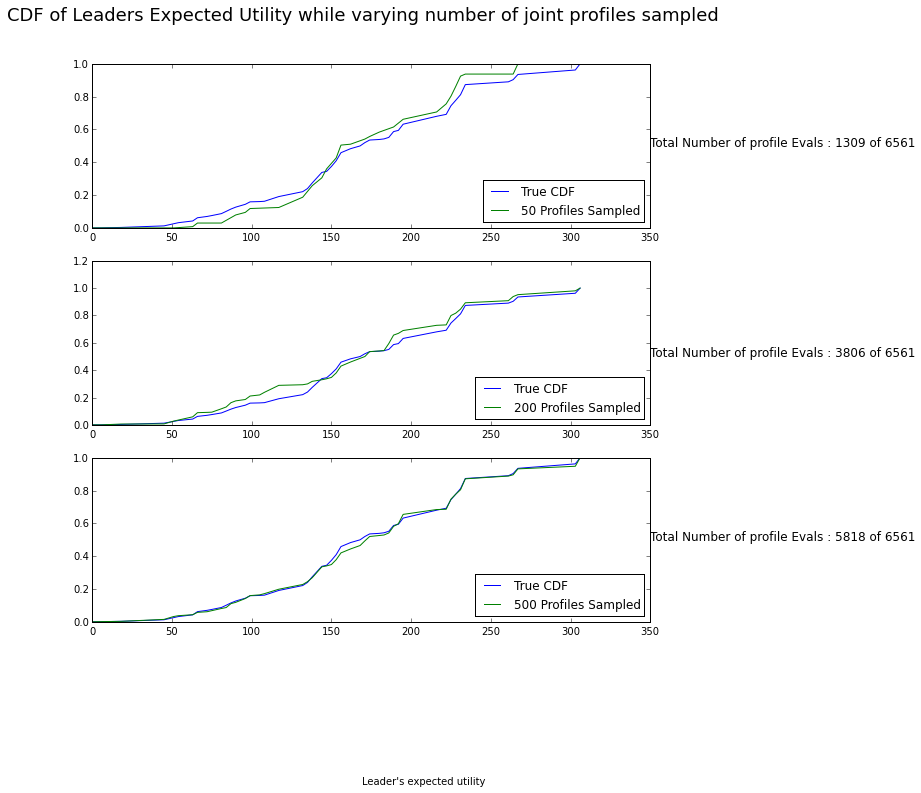

```python
fig, (ax1, ax2, ax3) = plt.subplots(3, figsize=(10,10))
ax1.plot(exhaustive_cdf[1], exhaustive_cdf[2], label = "True CDF")
ax2.plot(exhaustive_cdf[1], exhaustive_cdf[2], label = "True CDF")
ax3.plot(exhaustive_cdf[1], exhaustive_cdf[2], label = "True CDF")
ax1.plot(cdf_p2_20_numtotal50[1], cdf_p2_20_numtotal50[2], label="50 Profiles Sampled")
ax2.plot(cdf_p2_20_numtotal200[1], cdf_p2_20_numtotal200[2], label = "200 Profiles Sampled")
ax3.plot(cdf_p2_20_numtotal500[1], cdf_p2_20_numtotal500[2], label = "500 Profiles Sampled")
ax1.legend(loc=4)
ax2.legend(loc=4)
ax3.legend(loc=4)
ax1.text(350,.5, "Total Number of profile Evals : " +str(p2_20_numtotal50[4][-1]) + " of 6561", size=12)
ax2.text(350,.5, "Total Number of profile Evals : " +str(p2_20_numtotal200[4][-1]) + " of 6561", size=12)
ax3.text(350,.5, "Total Number of profile Evals : " +str(p2_20_numtotal500[4][-1]) + " of 6561", size=12)
fig.suptitle("CDF of Leaders Expected Utility while varying number of joint profiles sampled", size=18)
fig.text(.5, -.1, "Leader\'s expected utility")
```

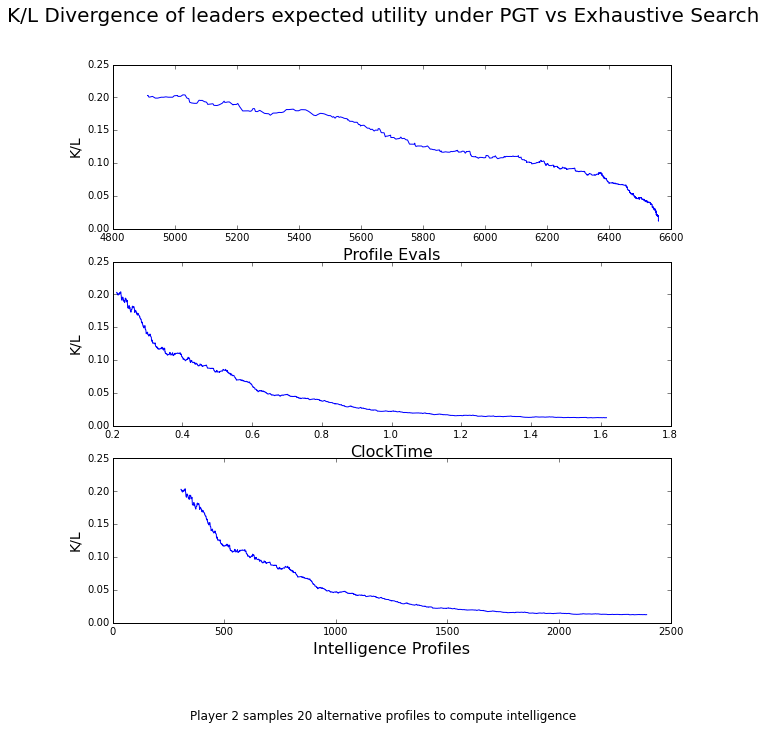

```python
p2_20_numtotal3000= Game.simple_pgt_with_memory(3000, 9, 20)
cdf_p2_20_numtotal3000= Game.exhaustive_distribution(p1eudist, jointprofiles=p2_20_numtotal3000[0],
                                                   intels=p2_20_numtotal3000[1])
kl_lots = Game.get_kl_divergence_plot(p2_20_numtotal3000[1], p2_20_numtotal3000[0], p1eudist)
fig, (ax1, ax2, ax3) = plt.subplots(3, figsize=(10,10))
ax1.plot(p2_20_numtotal3000[-1], kl_lots, label= "KL Divergence")
ax1.set_ylabel("K/L", size=14)
ax1.set_xlabel("Profile Evals", size=16)
fig.suptitle("K/L Divergence of leaders expected utility under PGT vs Exhaustive Search", size=20)

ax2.plot(p2_20_numtotal3000[-2], kl_lots, label= "KL Divergence")
ax2.set_ylabel("K/L", size=14)
ax2.set_xlabel("ClockTime", size=16)
#fig.suptitle("K/L Divergence of leaders expected utility under PGT vs Exhaustive Search", size=20)

ax3.plot(np.arange(1, len(kl_lots)+1, 1), kl_lots)
ax3.set_ylabel("K/L", size=14)
ax3.set_xlabel("Intelligence Profiles", size=16)
#fig.suptitle("K/L Divergence of leaders expected utility under PGT vs Exhaustive Search", size=20)
fig.text(.5, -.01, "Player 2 samples 20 alternative profiles to compute intelligence", ha='center', size=12)
```

###### Same experiment, except player 2 samples more alternative profiles

```python
Game = OneRoundPerfectInformationStackelbergGame( nature_space, l_actions, f_actions,
                                                l_mc, f_mc, nature_probs)

p1eudist = lambda x, y : Game.get_EU(x,y)[0]
# Get exhaustive CDF
exhaustive_cdf = Game.exhaustive_distribution(p1eudist)
# Do MonteCarlo
p2_30_numtotal50= Game.simple_pgt_with_memory(50, 9, 30)
p2_30_numtotal200= Game.simple_pgt_with_memory(200, 9, 30)
p2_30_numtotal500= Game.simple_pgt_with_memory(500, 9, 30)
cdf_p2_30_numtotal50= Game.exhaustive_distribution(p1eudist, jointprofiles=p2_30_numtotal50[0],
                                                   intels=p2_30_numtotal50[1])
cdf_p2_30_numtotal200= Game.exhaustive_distribution(p1eudist, jointprofiles=p2_30_numtotal200[0],
                                                   intels=p2_30_numtotal200[1])
cdf_p2_30_numtotal500= Game.exhaustive_distribution(p1eudist, jointprofiles=p2_30_numtotal500[0],
                                                   intels=p2_30_numtotal500[1])
```

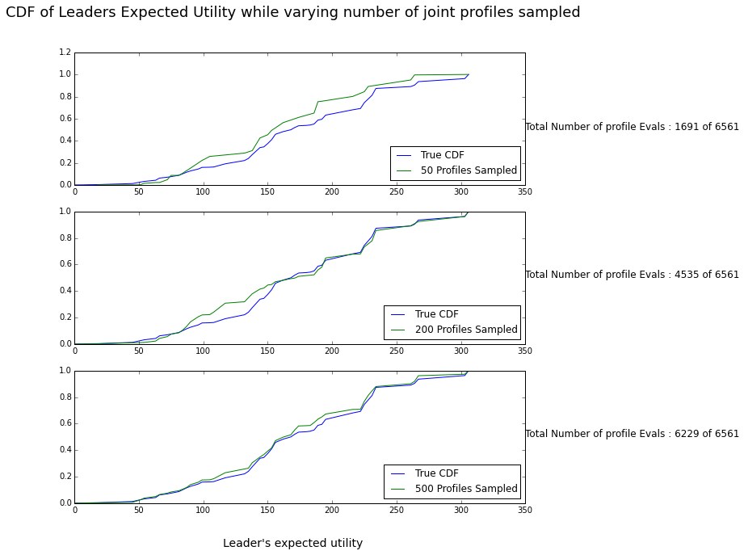

```python
fig, (ax1, ax2, ax3) = plt.subplots(3, figsize=(10,10))
ax1.plot(exhaustive_cdf[1], exhaustive_cdf[2], label = "True CDF")
ax2.plot(exhaustive_cdf[1], exhaustive_cdf[2], label = "True CDF")
ax3.plot(exhaustive_cdf[1], exhaustive_cdf[2], label = "True CDF")
ax1.plot(cdf_p2_30_numtotal50[1], cdf_p2_30_numtotal50[2], label="50 Profiles Sampled")
ax2.plot(cdf_p2_30_numtotal200[1], cdf_p2_30_numtotal200[2], label = "200 Profiles Sampled")
ax3.plot(cdf_p2_30_numtotal500[1], cdf_p2_30_numtotal500[2], label = "500 Profiles Sampled")
ax1.legend(loc=4)
ax2.legend(loc=4)
ax3.legend(loc=4)
ax1.text(350,.5, "Total Number of profile Evals : " +str(p2_30_numtotal50[4][-1]) + " of 6561", size=12)
ax2.text(350,.5, "Total Number of profile Evals : " +str(p2_30_numtotal200[4][-1]) + " of 6561", size=12)
ax3.text(350,.5, "Total Number of profile Evals : " +str(p2_30_numtotal500[4][-1]) + " of 6561", size=12)
fig.suptitle("CDF of Leaders Expected Utility while varying number of joint profiles sampled", size=18)
fig.text(.5, .05, "Leader\'s expected utility", size=14,ha='center')
```

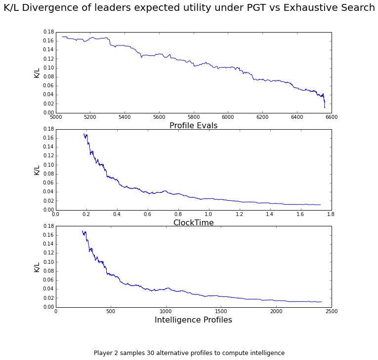

```python
p2_30_numtotal3000= Game.simple_pgt_with_memory(3000, 9, 30)
cdf_p2_30_numtotal3000= Game.exhaustive_distribution(p1eudist, jointprofiles=p2_30_numtotal3000[0],
                                                   intels=p2_30_numtotal3000[1])
kl_lots = Game.get_kl_divergence_plot(p2_30_numtotal3000[1], p2_30_numtotal3000[0], p1eudist)
fig, (ax1, ax2, ax3) = plt.subplots(3, figsize=(10,10))
ax1.plot(p2_30_numtotal3000[-1], kl_lots, label= "KL Divergence")
ax1.set_ylabel("K/L", size=14)
ax1.set_xlabel("Profile Evals", size=16)
fig.suptitle("K/L Divergence of leaders expected utility under PGT vs Exhaustive Search", size=20)

ax2.plot(p2_30_numtotal3000[-2], kl_lots, label= "KL Divergence")
ax2.set_ylabel("K/L", size=14)
ax2.set_xlabel("ClockTime", size=16)
#fig.suptitle("K/L Divergence of leaders expected utility under PGT vs Exhaustive Search", size=20)

ax3.plot(np.arange(1, len(kl_lots)+1, 1), kl_lots)
ax3.set_ylabel("K/L", size=14)
ax3.set_xlabel("Intelligence Profiles", size=16)
#fig.suptitle("K/L Divergence of leaders expected utility under PGT vs Exhaustive Search", size=20)
fig.text(.5, -.01, "Player 2 samples 30 alternative profiles to compute intelligence", ha='center', size=12)
```